# Visualizing COVID-19 hospitalizations in the US with *choromap*

**Javier Orman**  
GitHub repository for this ChoroMap: https://github.com/javierorman/choromap/  
LinkedIn: https://www.linkedin.com/in/javierorman/

Latest update: 1/28/2021

## 1. Introduction

In this notebook I showcase the use of the module **choromap**, which produces **animated choropleth maps**, to visualize the spread of COVID-19 in the United States. Data will be retrieved from the API of *The COVID Tracking Project at The Atlantic* and merged with US Census population data to calculate **hospitalization rates** for each state.

### Import dependencies

Data will be imported and organized with *pandas*. *Geopandas* will be used to work with geospatial data and visualizations will be made with *matplotlib*.

```python
import pandas as pd
pd.set_option('display.max_columns', None)

import geopandas as gpd

import requests

import os
import sys

from matplotlib import colors
from matplotlib import pyplot as plt
```

Set *module_path* for the directory containing the module *choromap*

```python
from pathlib import Path

module_path = str(Path.cwd().parent)

if module_path not in sys.path:
    sys.path.append(module_path)
```

Next, import classes *ChoroMapBuilder* and *DataFramePrepper* from module *choromap*. The module is [available on GitHub](https://github.com/javierorman/choromap).

```python
from choromap import ChoroMapBuilder, DataFramePrepper
```

## 2. COVID-19 data for each State

The data used here is available from the API of *The COVID Tracking Project at The Atlantic"*. More information [here](https://covidtracking.com/data/api).

```python
us_covid_df = pd.read_csv('https://covidtracking.com/api/v1/states/daily.csv')
us_covid_df
```

|  | date | state | positive | probableCases | negative | pending | totalTestResultsSource | totalTestResults | hospitalizedCurrently | hospitalizedCumulative | inIcuCurrently | inIcuCumulative | onVentilatorCurrently | onVentilatorCumulative | recovered | dataQualityGrade | lastUpdateEt | dateModified | checkTimeEt | death | hospitalized | dateChecked | totalTestsViral | positiveTestsViral | negativeTestsViral | positiveCasesViral | deathConfirmed | deathProbable | totalTestEncountersViral | … |
| --- | --- | --- | --- | --- | --- | --- | --- | --- | --- | --- | --- | --- | --- | --- | --- | --- | --- | --- | --- | --- | --- | --- | --- | --- | --- | --- | --- | --- | --- | --- |
| 0 | 20210128 | AK | 52150.0 | NaN | NaN | NaN | totalTestsViral | 1479849.0 | 42.0 | 1201.0 | NaN | NaN | 5.0 | NaN | NaN | A | 1/28/2021 03:59 | 2021-01-28T03:59:00Z | 01/27 22:59 | 262.0 | 1201.0 | 2021-01-28T03:59:00Z | 1479849.0 | 62705.0 | 1415473.0 | NaN | NaN | NaN | NaN | … |
| 1 | 20210128 | AL | 452734.0 | 95263.0 | 1759171.0 | NaN | totalTestsPeopleViral | 2116642.0 | 2052.0 | 41483.0 | NaN | 2533.0 | NaN | 1449.0 | 242143.0 | A | 1/28/2021 11:00 | 2021-01-28T11:00:00Z | 01/28 06:00 | 7340.0 | 41483.0 | 2021-01-28T11:00:00Z | NaN | NaN | NaN | 357471.0 | 5928.0 | 1412.0 | NaN | … |
| 2 | 20210128 | AR | 290856.0 | 58518.0 | 2161833.0 | NaN | totalTestsViral | 2394171.0 | 996.0 | 13505.0 | 307.0 | NaN | 143.0 | 1414.0 | 268495.0 | A+ | 1/28/2021 00:00 | 2021-01-28T00:00:00Z | 01/27 19:00 | 4784.0 | 13505.0 | 2021-01-28T00:00:00Z | 2394171.0 | NaN | 2161833.0 | 232338.0 | 3864.0 | 920.0 | NaN | … |
| 3 | 20210128 | AS | 0.0 | NaN | 2140.0 | NaN | totalTestsViral | 2140.0 | NaN | NaN | NaN | NaN | NaN | NaN | NaN | NaN | 12/1/2020 00:00 | 2020-12-01T00:00:00Z | 11/30 19:00 | 0.0 | NaN | 2020-12-01T00:00:00Z | 2140.0 | NaN | NaN | 0.0 | NaN | NaN | NaN | … |
| 4 | 20210128 | AZ | 743232.0 | 46684.0 | 2712847.0 | NaN | totalTestsViral | 6549568.0 | 4087.0 | 51349.0 | 1023.0 | NaN | 692.0 | NaN | 101104.0 | A+ | 1/28/2021 00:00 | 2021-01-28T00:00:00Z | 01/27 19:00 | 12819.0 | 51349.0 | 2021-01-28T00:00:00Z | 6549568.0 | NaN | NaN | 696548.0 | 11440.0 | 1379.0 | NaN | … |
| ... | ... | ... | ... | ... | ... | ... | ... | ... | ... | ... | ... | ... | ... | ... | ... | ... | ... | ... | ... | ... | ... | ... | ... | ... | ... | ... | ... | ... | ... | … |
| 18637 | 20200117 | WA | 0.0 | NaN | NaN | NaN | totalTestEncountersViral | NaN | NaN | NaN | NaN | NaN | NaN | NaN | NaN | NaN | NaN | NaN | NaN | NaN | NaN | NaN | NaN | NaN | NaN | 0.0 | NaN | NaN | NaN | … |
| 18638 | 20200116 | WA | 0.0 | NaN | NaN | NaN | totalTestEncountersViral | NaN | NaN | NaN | NaN | NaN | NaN | NaN | NaN | NaN | NaN | NaN | NaN | NaN | NaN | NaN | NaN | NaN | NaN | 0.0 | NaN | NaN | NaN | … |
| 18639 | 20200115 | WA | 0.0 | NaN | NaN | NaN | totalTestEncountersViral | NaN | NaN | NaN | NaN | NaN | NaN | NaN | NaN | NaN | NaN | NaN | NaN | NaN | NaN | NaN | NaN | NaN | NaN | 0.0 | NaN | NaN | NaN | … |
| 18640 | 20200114 | WA | 0.0 | NaN | NaN | NaN | totalTestEncountersViral | NaN | NaN | NaN | NaN | NaN | NaN | NaN | NaN | NaN | NaN | NaN | NaN | NaN | NaN | NaN | NaN | NaN | NaN | 0.0 | NaN | NaN | NaN | … |
| 18641 | 20200113 | WA | NaN | NaN | NaN | NaN | totalTestEncountersViral | NaN | NaN | NaN | NaN | NaN | NaN | NaN | NaN | NaN | NaN | NaN | NaN | NaN | NaN | NaN | NaN | NaN | NaN | NaN | NaN | NaN | NaN | … |

18642 rows × 55 columns

Here are the variables available in the data:

```python
us_covid_df.columns
```

```
Index(['date', 'state', 'positive', 'probableCases', 'negative', 'pending',
       'totalTestResultsSource', 'totalTestResults', 'hospitalizedCurrently',
       'hospitalizedCumulative', 'inIcuCurrently', 'inIcuCumulative',
       'onVentilatorCurrently', 'onVentilatorCumulative', 'recovered',
       'dataQualityGrade', 'lastUpdateEt', 'dateModified', 'checkTimeEt',
       'death', 'hospitalized', 'dateChecked', 'totalTestsViral',
       'positiveTestsViral', 'negativeTestsViral', 'positiveCasesViral',
       'deathConfirmed', 'deathProbable', 'totalTestEncountersViral',
       'totalTestsPeopleViral', 'totalTestsAntibody', 'positiveTestsAntibody',
       'negativeTestsAntibody', 'totalTestsPeopleAntibody',
       'positiveTestsPeopleAntibody', 'negativeTestsPeopleAntibody',
       'totalTestsPeopleAntigen', 'positiveTestsPeopleAntigen',
       'totalTestsAntigen', 'positiveTestsAntigen', 'fips', 'positiveIncrease',
       'negativeIncrease', 'total', 'totalTestResultsIncrease', 'posNeg',
       'deathIncrease', 'hospitalizedIncrease', 'hash', 'commercialScore',
       'negativeRegularScore', 'negativeScore', 'positiveScore', 'score',
       'grade'],
      dtype='object')
```

Next we change the format of the dates from *yyyymmdd* to *yyyy-mm-dd*.

```python
def to_iso(date):
    """
    Convert a date (str) from yyyymmdd to yyyy-mm-dd,
    e.g. 20200128 -> 2020-01-28
    """
    x = str(date)
    return x[0:4] + '-' + x[4:6] + '-' + x[6:8]
```

```python
us_covid_df['date'] = us_covid_df['date'].apply(lambda x: to_iso(x))
```

```python
# First 5 rows
us_covid_df.head(5)
```

|  | date | state | positive | probableCases | negative | pending | totalTestResultsSource | totalTestResults | hospitalizedCurrently | hospitalizedCumulative | inIcuCurrently | inIcuCumulative | onVentilatorCurrently | onVentilatorCumulative | recovered | dataQualityGrade | lastUpdateEt | dateModified | checkTimeEt | death | hospitalized | dateChecked | totalTestsViral | positiveTestsViral | negativeTestsViral | positiveCasesViral | deathConfirmed | deathProbable | totalTestEncountersViral | … |
| --- | --- | --- | --- | --- | --- | --- | --- | --- | --- | --- | --- | --- | --- | --- | --- | --- | --- | --- | --- | --- | --- | --- | --- | --- | --- | --- | --- | --- | --- | --- |
| 0 | 2021-01-28 | AK | 52150.0 | NaN | NaN | NaN | totalTestsViral | 1479849.0 | 42.0 | 1201.0 | NaN | NaN | 5.0 | NaN | NaN | A | 1/28/2021 03:59 | 2021-01-28T03:59:00Z | 01/27 22:59 | 262.0 | 1201.0 | 2021-01-28T03:59:00Z | 1479849.0 | 62705.0 | 1415473.0 | NaN | NaN | NaN | NaN | … |
| 1 | 2021-01-28 | AL | 452734.0 | 95263.0 | 1759171.0 | NaN | totalTestsPeopleViral | 2116642.0 | 2052.0 | 41483.0 | NaN | 2533.0 | NaN | 1449.0 | 242143.0 | A | 1/28/2021 11:00 | 2021-01-28T11:00:00Z | 01/28 06:00 | 7340.0 | 41483.0 | 2021-01-28T11:00:00Z | NaN | NaN | NaN | 357471.0 | 5928.0 | 1412.0 | NaN | … |
| 2 | 2021-01-28 | AR | 290856.0 | 58518.0 | 2161833.0 | NaN | totalTestsViral | 2394171.0 | 996.0 | 13505.0 | 307.0 | NaN | 143.0 | 1414.0 | 268495.0 | A+ | 1/28/2021 00:00 | 2021-01-28T00:00:00Z | 01/27 19:00 | 4784.0 | 13505.0 | 2021-01-28T00:00:00Z | 2394171.0 | NaN | 2161833.0 | 232338.0 | 3864.0 | 920.0 | NaN | … |
| 3 | 2021-01-28 | AS | 0.0 | NaN | 2140.0 | NaN | totalTestsViral | 2140.0 | NaN | NaN | NaN | NaN | NaN | NaN | NaN | NaN | 12/1/2020 00:00 | 2020-12-01T00:00:00Z | 11/30 19:00 | 0.0 | NaN | 2020-12-01T00:00:00Z | 2140.0 | NaN | NaN | 0.0 | NaN | NaN | NaN | … |
| 4 | 2021-01-28 | AZ | 743232.0 | 46684.0 | 2712847.0 | NaN | totalTestsViral | 6549568.0 | 4087.0 | 51349.0 | 1023.0 | NaN | 692.0 | NaN | 101104.0 | A+ | 1/28/2021 00:00 | 2021-01-28T00:00:00Z | 01/27 19:00 | 12819.0 | 51349.0 | 2021-01-28T00:00:00Z | 6549568.0 | NaN | NaN | 696548.0 | 11440.0 | 1379.0 | NaN | … |

## 3. Population data

Because we are interested in the *rate of hospitalizations* in each state, we need import population data. Here we use a dataset from the US Census, [available here](https://www2.census.gov/programs-surveys/popest/tables/2010-2019/state/totals/nst-est2019-01.xlsx).

```python
census_df = pd.read_excel('datasets/nst-est2019-01.xlsx', engine="openpyxl")
```

```python
# Eliminate unnecessary rows and columns
census_df = census_df.iloc[8:59, [0, -1]].reset_index(drop=True)
census_df.columns = ['state_full', 'population']

# First 5 rows
census_df.head()
```

|  | state_full | population |
| --- | --- | --- |
| 0 | .Alabama | 4903185.0 |
| 1 | .Alaska | 731545.0 |
| 2 | .Arizona | 7278717.0 |
| 3 | .Arkansas | 3017804.0 |
| 4 | .California | 39512223.0 |

```python
# Eliminate unnecessary characters
census_df['state_full'] = census_df['state_full'].str.replace('.', '')
census_df.head()
```

|  | state_full | population |
| --- | --- | --- |
| 0 | Alabama | 4903185.0 |
| 1 | Alaska | 731545.0 |
| 2 | Arizona | 7278717.0 |
| 3 | Arkansas | 3017804.0 |
| 4 | California | 39512223.0 |

Because the states in *us_covid_df* are represented by 2-letter codes, we will use [this dataset](https://worldpopulationreview.com/states/state-abbreviations) to properly format *census_df*.

```python
codes_df = pd.read_csv('datasets/codes_data.csv')
```

```python
codes_df.head()
```

|  | State | Abbrev | Code |
| --- | --- | --- | --- |
| 0 | Alabama | Ala. | AL |
| 1 | Alaska | Alaska | AK |
| 2 | Arizona | Ariz. | AZ |
| 3 | Arkansas | Ark. | AR |
| 4 | California | Calif. | CA |

```python
# Merge census_df and codes_df
pop_df = codes_df.merge(census_df, left_on='State', right_on='state_full', how='inner')

# Eliminate unnecessary columns
pop_df = pop_df.iloc[:, [2, 4]]

# Rename columns
pop_df.columns = ['state', 'population']

# Show the first 5 columns
pop_df.head()
```

|  | state | population |
| --- | --- | --- |
| 0 | AL | 4903185.0 |
| 1 | AK | 731545.0 |
| 2 | AZ | 7278717.0 |
| 3 | AR | 3017804.0 |
| 4 | CA | 39512223.0 |

```python
# Merge pop_df and covid_df
us_covid_df = us_covid_df.merge(pop_df, on='state', how='left')
us_covid_df.head()
```

|  | date | state | positive | probableCases | negative | pending | totalTestResultsSource | totalTestResults | hospitalizedCurrently | hospitalizedCumulative | inIcuCurrently | inIcuCumulative | onVentilatorCurrently | onVentilatorCumulative | recovered | dataQualityGrade | lastUpdateEt | dateModified | checkTimeEt | death | hospitalized | dateChecked | totalTestsViral | positiveTestsViral | negativeTestsViral | positiveCasesViral | deathConfirmed | deathProbable | totalTestEncountersViral | … |
| --- | --- | --- | --- | --- | --- | --- | --- | --- | --- | --- | --- | --- | --- | --- | --- | --- | --- | --- | --- | --- | --- | --- | --- | --- | --- | --- | --- | --- | --- | --- |
| 0 | 2021-01-28 | AK | 52150.0 | NaN | NaN | NaN | totalTestsViral | 1479849.0 | 42.0 | 1201.0 | NaN | NaN | 5.0 | NaN | NaN | A | 1/28/2021 03:59 | 2021-01-28T03:59:00Z | 01/27 22:59 | 262.0 | 1201.0 | 2021-01-28T03:59:00Z | 1479849.0 | 62705.0 | 1415473.0 | NaN | NaN | NaN | NaN | … |
| 1 | 2021-01-28 | AL | 452734.0 | 95263.0 | 1759171.0 | NaN | totalTestsPeopleViral | 2116642.0 | 2052.0 | 41483.0 | NaN | 2533.0 | NaN | 1449.0 | 242143.0 | A | 1/28/2021 11:00 | 2021-01-28T11:00:00Z | 01/28 06:00 | 7340.0 | 41483.0 | 2021-01-28T11:00:00Z | NaN | NaN | NaN | 357471.0 | 5928.0 | 1412.0 | NaN | … |
| 2 | 2021-01-28 | AR | 290856.0 | 58518.0 | 2161833.0 | NaN | totalTestsViral | 2394171.0 | 996.0 | 13505.0 | 307.0 | NaN | 143.0 | 1414.0 | 268495.0 | A+ | 1/28/2021 00:00 | 2021-01-28T00:00:00Z | 01/27 19:00 | 4784.0 | 13505.0 | 2021-01-28T00:00:00Z | 2394171.0 | NaN | 2161833.0 | 232338.0 | 3864.0 | 920.0 | NaN | … |
| 3 | 2021-01-28 | AS | 0.0 | NaN | 2140.0 | NaN | totalTestsViral | 2140.0 | NaN | NaN | NaN | NaN | NaN | NaN | NaN | NaN | 12/1/2020 00:00 | 2020-12-01T00:00:00Z | 11/30 19:00 | 0.0 | NaN | 2020-12-01T00:00:00Z | 2140.0 | NaN | NaN | 0.0 | NaN | NaN | NaN | … |
| 4 | 2021-01-28 | AZ | 743232.0 | 46684.0 | 2712847.0 | NaN | totalTestsViral | 6549568.0 | 4087.0 | 51349.0 | 1023.0 | NaN | 692.0 | NaN | 101104.0 | A+ | 1/28/2021 00:00 | 2021-01-28T00:00:00Z | 01/27 19:00 | 12819.0 | 51349.0 | 2021-01-28T00:00:00Z | 6549568.0 | NaN | NaN | 696548.0 | 11440.0 | 1379.0 | NaN | … |

```python
# Create column 'hosp_curr_100000' with the rate of hospitalizations per 100000 residents in each State.
us_covid_df['hosp_curr_100000'] = (us_covid_df['hospitalizedCurrently'] / us_covid_df['population']) * 100000
```

## 4. Geographic data

The geospatial shapefiles for drawing the map of the United States are available [here](https://www.arcgis.com/home/item.html?id=f7f805eb65eb4ab787a0a3e1116ca7e5#).

```python
filepath = 'shapefiles/states_21basic/states.shp'
us_geom_df = gpd.read_file(filepath)
```

Take out Alaska and Hawaii to keep a practical view of the map.

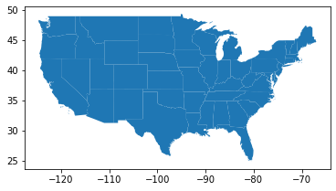

```python
us_geom_df = us_geom_df[us_geom_df['STATE_ABBR'].isin(['AK', 'HI']) == False]
us_geom_df.plot()
```

## 5. Map

The module *choromap* includes two classes: ChoroMapBuilder, which has the methods necessary to make the maps and DataFramePrepper, which prepares the dataframes to pass to ChoroMapBuilder.

DataFramePrepper takes two parameters: *info_df* and *geom_df*.

1. *us_covid_df* is our informational DataFrame with dates, locations and values (rate of hospitalizations in this case) and is passed as *info_df*.
2. *us_geom_df* is our geometric DataFrame with locations and the vector information to draw the shapes of the states. It's passed as *geom_df*.

```python
prepper = DataFramePrepper(info_df=us_covid_df, geom_df=us_geom_df)
```

```python
# Prepare the informational DataFrame by selecting the columns to focus on.
# roll_avg being True means that daily values of hospitalizations will be smoothed out through a 7-day window average.
prepper.prep_info_df(category='hosp_curr_100000', col_dates='date', col_location='state', roll_avg=True)

# Prepare geometric DataFrame
prepper.prep_geom_df(location_col='STATE_ABBR', geometry_col='geometry')

# Merged the info_df and geom_df
merged_df = prepper.merge_info_geom()

# Show top 5 rows of merged_df
merged_df.head()
```

| location | geometry | 2020-01-13 | 2020-01-14 | 2020-01-15 | 2020-01-16 | 2020-01-17 | 2020-01-18 | 2020-01-19 | 2020-01-20 | 2020-01-21 | 2020-01-22 | 2020-01-23 | 2020-01-24 | 2020-01-25 | 2020-01-26 | 2020-01-27 | 2020-01-28 | 2020-01-29 | 2020-01-30 | 2020-01-31 | 2020-02-01 | 2020-02-02 | 2020-02-03 | 2020-02-04 | 2020-02-05 | 2020-02-06 | 2020-02-07 | 2020-02-08 | 2020-02-09 | … |
| --- | --- | --- | --- | --- | --- | --- | --- | --- | --- | --- | --- | --- | --- | --- | --- | --- | --- | --- | --- | --- | --- | --- | --- | --- | --- | --- | --- | --- | --- | --- |
| WA | MULTIPOLYGON (((-122.40202 48.22522, -122.4628... | 0.0 | 0.0 | 0.0 | 0.0 | 0.0 | 0.0 | 0.0 | 0.0 | 0.0 | 0.0 | 0.0 | 0.0 | 0.0 | 0.0 | 0.0 | 0.0 | 0.0 | 0.0 | 0.0 | 0.0 | 0.0 | 0.0 | 0.0 | 0.0 | 0.0 | 0.0 | 0.0 | 0.0 | … |
| MT | POLYGON ((-111.47543 44.70216, -111.48080 44.6... | 0.0 | 0.0 | 0.0 | 0.0 | 0.0 | 0.0 | 0.0 | 0.0 | 0.0 | 0.0 | 0.0 | 0.0 | 0.0 | 0.0 | 0.0 | 0.0 | 0.0 | 0.0 | 0.0 | 0.0 | 0.0 | 0.0 | 0.0 | 0.0 | 0.0 | 0.0 | 0.0 | 0.0 | … |
| ME | MULTIPOLYGON (((-69.77728 44.07415, -69.85993 ... | 0.0 | 0.0 | 0.0 | 0.0 | 0.0 | 0.0 | 0.0 | 0.0 | 0.0 | 0.0 | 0.0 | 0.0 | 0.0 | 0.0 | 0.0 | 0.0 | 0.0 | 0.0 | 0.0 | 0.0 | 0.0 | 0.0 | 0.0 | 0.0 | 0.0 | 0.0 | 0.0 | 0.0 | … |
| ND | POLYGON ((-98.73044 45.93827, -99.00683 45.939... | 0.0 | 0.0 | 0.0 | 0.0 | 0.0 | 0.0 | 0.0 | 0.0 | 0.0 | 0.0 | 0.0 | 0.0 | 0.0 | 0.0 | 0.0 | 0.0 | 0.0 | 0.0 | 0.0 | 0.0 | 0.0 | 0.0 | 0.0 | 0.0 | 0.0 | 0.0 | 0.0 | 0.0 | … |
| SD | POLYGON ((-102.78838 42.99530, -103.00588 42.9... | 0.0 | 0.0 | 0.0 | 0.0 | 0.0 | 0.0 | 0.0 | 0.0 | 0.0 | 0.0 | 0.0 | 0.0 | 0.0 | 0.0 | 0.0 | 0.0 | 0.0 | 0.0 | 0.0 | 0.0 | 0.0 | 0.0 | 0.0 | 0.0 | 0.0 | 0.0 | 0.0 | 0.0 | … |

```python
builder = ChoroMapBuilder(merged_df=merged_df)
```

Next we build the maps using the ChoroMapBuilder method *make_map*. Here is the documentation on it:

```python
help(ChoroMapBuilder.make_map)
```

```
Help on function make_map in module choromap:

make_map(self, title, subtitle, unit, save_name, labels=True, lang='en', fig_size=(16, 8), color='OrRd', count='all', begin_date=None, norm=<class 'matplotlib.colors.Normalize'>, fps=8)
    It calls for the whole process of creating the maps and turning them into videos.

    Parameters:
        title : str
            Title to be displayed above the map
        subtitle : str
            Possible use is to reference the source of the data
        unit : str
            Units for colorbar
        save_name : str
            Name to be used in exports (static map images, gifs, videos) and directory paths
        labels : bool
            If true, the make_static_maps method will insert labels in -hopefully- safe regions of the map
        lang : language code for babel.format_date, passed to pretty_date method
        fig_size : tuple (height, width)
            Size for the figure.
        color : passes to cmap option in Pandas plot function, which in turn uses Matplotlib Colormaps.
            Information and options here: https://matplotlib.org/3.1.0/tutorials/colors/colormaps.html
            Some of my favorites are 'OrRd', 'gist_heat_r', 'copper_r' .
            (the _r at the end reverses the color sequence)
        count : 'all' or int > 1
            Number of maps to be created.
        begin_date : str
            Date formatted as yyyy-mm-dd to match dates in merged_df
        norm : Normalization class to use for mapping values into the colormap.
            The classes are part of Matplotlib module colors.
            colors.Normalize provides linear normalization
            colors.LogNorm provides logarithmic normalization
        fps : int
            Frames per second - passed to make_gif method,
            then as an argument to gifski
```

```python
builder.make_map(title='Rate of current COVID-19 hospitalizations in each state',
                      subtitle='Source: The COVID Tracking Project at The Atlantic',
                      unit='COVID-19 hospitalizations per 100,000 residents',
                      save_name='hosp_curr_us_100000',
                      count='all', begin_date='2020-03-01',
                      color='Reds', fps=6)
```

[video not shown]